# Escherichia coli Data Exploration in the Upper Santa Cruz River

## Processing the USGS File

### Notes

This data is from the USGS continuous monitoring gage of the Santa Cruz River at Tubac. Data is all published and available for public use.

### Code

Triple hashes (###) within code blocks are meant to indicate code that has been commented-out or added in order to expedite the processing (by use of a saved csv file of processed data rather than repeating the processing each time). If code is fully automated, these chunks are to be altered. # Original code may be un-commented and re-run if desired. Data after 1/10/2022 are currently provisional and is still subject to change during USGS QAQC procedures.

```r
# Inputs formatted for read NWIS function.
site_id <- '09481740'
startDate = "2009-06-01"
endDate = "2022-08-30" # End date is 8/30/2022 to avoid null data at this time (9/5/2022)

# Input timezone for read NWIS and POSIXT functions
tz="America/Phoenix"

#### Creates table in R
###USGS_Raw <- readNWISuv(site_id,c('00060','00065'), startDate,endDate, tz)

###Read in raw data. If using code above, do not run this line.
USGS_Raw <- read.csv("Data/Raw/USGS_09481740.csv")
```

2015 had some times that were off by a few minutes from the normal 15- minute interval. This will ensure that everything is standardized. Values are rounded to the nearest 15-minute interval.

```r
# Create a New Dataframe to edit. I prefer to keep the old data available during this process in order to be able to quickly compare.
USGS_Standardized <- USGS_Raw

# Round data and put into a format for merging.
# DateTime2 is used throughout this notebook to indicate the processed DateTime.
USGS_Standardized$DateTime2 <- round_date(as.POSIXct(USGS_Standardized$dateTime), "15 minutes")
USGS_Standardized$DateTime2 <-as.POSIXct(format(USGS_Standardized$DateTime2, format = '%Y-%m-%d %H:%M'), tz = tz)
```

There are duplicate entries which have arisen from the 15-minute standardization, continuing the issues from 2015. Some separate values could be rounded to the same DateTime.

```r
# Determines how many values are affected by the rounding process (and any other duplicates)
USGS_Standardized %>%
  group_by(DateTime2) %>%
  summarise(n=sum(n())) %>% filter(n>1)
```

| DateTime2 | n |
| --- | --- |
| 2013-02-02 12:45:00 | 2 |
| 2013-02-02 13:00:00 | 2 |
| 2013-02-02 13:15:00 | 2 |
| 2013-02-03 12:45:00 | 2 |
| 2013-02-03 13:00:00 | 2 |
| 2013-02-03 13:15:00 | 2 |
| 2013-02-04 12:45:00 | 2 |
| 2013-02-04 13:00:00 | 2 |
| 2013-02-04 13:15:00 | 2 |
| 2013-02-05 12:45:00 | 2 |

[output cut: 739 more lines]

The duplicate DateTime can be fixed by using the mean of the values (they are within 15 minutes of one-another and should not be hugely variable). The mean will be used in place of the original two values.

```r
# Summarizes the flow column by the rounded DateTime. It will take the average of the two values if multiples exist.
USGS_Standardized_append <- USGS_Standardized %>% group_by(DateTime2) %>% summarise(mean(X_00060_00000))

# Rename the column to something meaningful.
setnames(USGS_Standardized_append,old=c("mean(X_00060_00000)"),new=c("Discharge_CFS"))

# Merge the rounded data back in and rename the column name to something meaningful.
USGS_Standardized<- merge(x=USGS_Standardized,y=USGS_Standardized_append, by="DateTime2",all.x=TRUE, all.y = FALSE)

# Remove the pre-averaging flow column.
USGS_Standardized <- USGS_Standardized %>%
  subset(select = -c(X_00060_00000)) %>%
  distinct(DateTime2, Discharge_CFS, .keep_all = TRUE)

# Re-check for duplicate values. This should equal zero.
USGS_Standardized %>% group_by(DateTime2) %>% summarise(n=sum(n())) %>% filter(n>1)
```

| DateTime2 | n |
| --- | --- |

```r
# Remove append table - data has been merged
rm(USGS_Standardized_append)
```

Though the data is nearly complete, there are still some missing values for the 15 minute intervals. Currently the missing rows are not included in the dataframe.

This will create a full time series to include indicator of no data.

```r
# Create the time series, formatted as POSIXct
TimeSeries <- data.frame(seq.POSIXt(as.POSIXct(format("2009-06-01 0:00",format = '%m/%d/%y %H:%M'), tz = tz), as.POSIXct(format("2022-08-30 0:00",format = '%m/%d/%y %H:%M'), tz = tz), by="15 min"))

# Rename the Column DateTime2 to indicate properly formatted column.
colnames(TimeSeries)[1] = "DateTime2"

# Follow through  - properly format DateTime2
TimeSeries$DateTime2 <-as.POSIXct(format(TimeSeries$DateTime2, format = '%Y-%m-%d %H:%M'), tz = tz)

# Left join data with time series, sort by DateTime2
USGS_Standardized <- merge(x=TimeSeries,y=USGS_Standardized,by="DateTime2",all.x=TRUE, all.y = FALSE)

# Remove the created time series. Data has been merged
rm(TimeSeries)
```

Look at the data to ensure that it is doing what we want. I know that 7/1/2009 at 04:30 has no data.

```r
# View 7/1/2009 04:30
USGS_Standardized %>%
  filter(DateTime2 == '2009-07-01 04:30:00')
```

| DateTime2 | X | agency_cd | site_no | dateTime | X_00060_00000_cd | X_00065_00000 | X_00065_00000_cd | tz_cd | Discharge_CFS |
| --- | --- | --- | --- | --- | --- | --- | --- | --- | --- |
| 2009-07-01 04:30:00 | NA | NA | NA | NA | NA | NA | NA | NA | NA |

Now that nulls are created, lets try and reduce them.

```r
# Tests to see how many nulls are present in the current dataset.
# 9/5/2022: 40548 records are null
count(USGS_Standardized %>%
 filter(is.na(Discharge_CFS)))
```

| n |
| --- |
| 40548 |

We should be able to fill some of the nulls by taking the average of the two surrounding values.

```r
USGS_Standardized$date <- as_date(USGS_Standardized$DateTime2)
# Create a dummy column.
USGS_Standardized$count <- 1

# Count the number of readings per day
TimeFlag <- USGS_Standardized %>%
  filter(!is.na(Discharge_CFS)) %>%
  group_by(date) %>%
  summarize(value = sum(count))

# Append the reading count value to the standardized data
USGS_Standardized <- right_join(TimeFlag, USGS_Standardized)
# Name this something meaningful
setnames(USGS_Standardized, c("value", "X_00060_00000_cd", "X_00065_00000", "X_00065_00000_cd"), c("DailyFlowCount", "Discharge_cd", "USGS_Staff", "USGS_Staff_cd"), skip_absent = TRUE)

# Remove extraneous columns and reorder
USGS_Standardized <- USGS_Standardized %>%
  select(DateTime2, date, Discharge_CFS, USGS_Staff, Discharge_cd, tz_cd, DailyFlowCount)

# Remove Timeflag table. Merged into data
rm(TimeFlag)
```

Start to fill null data where applicable. This will fill in all data into a new column.

```r
#Filter for columns with a daily flow count greater than 88 (no more than 2 hours per day missing.)
USGS_Standardized_Fill <-
  USGS_Standardized %>%
  filter(DailyFlowCount>88)

# Fill in missing data
USGS_Standardized_Fill$Filled <-  na.approx(USGS_Standardized_Fill$Discharge_CFS, rule = 2)

#Join back in
USGS_Standardized <- right_join(USGS_Standardized_Fill,USGS_Standardized)
# Remove the old data
rm(USGS_Standardized_Fill,USGS_Raw)
```

Check how many nulls there are now that some of the data is filled. More data filled would mean more assumptions. 9/12/2022: Current count of null data is decreased to 37385

```r
# Fill in the un-filled values
USGS_Standardized$Filled<- ifelse(is.na(USGS_Standardized$Discharge_CFS) == TRUE,USGS_Standardized$Filled,USGS_Standardized$Discharge_CFS)

count(USGS_Standardized %>%
 filter(is.na(Filled)))
```

| n |
| --- |
| 37385 |

```r
NA
```

Clean up the columns nd environment

```r
#Remove the un-filled discharge column
USGS_Standardized <-  USGS_Standardized %>%
  subset(select = -c(Discharge_CFS))

#Rename to something meaningful
setnames(USGS_Standardized,old=c("Filled"),new=c("Discharge_CFS"))
```

#To determine if the river is rising, use quantiles

```r
CFS_Quantiles<- quantile(USGS_Standardized$Discharge_CFS, na.rm = TRUE)

USGS_Standardized <- USGS_Standardized %>%
  mutate(DisDif = Discharge_CFS - lag(Discharge_CFS))

# This will create a binary variable or either rise of fall. Rise = 1, fall = 0. It will allow me to more easily create summary statistics.
USGS_Standardized$DisDif2 <- ifelse(USGS_Standardized$DisDif>0,1,0)

# Create a numeric classifier.
# 1 = Low Flow, 2 = Base flow, 3 = High and Rising Flow 4 = High and Falling Flow
USGS_Standardized$Stage <- ifelse(USGS_Standardized$Discharge_CFS<=CFS_Quantiles[2], 1,
  ifelse(USGS_Standardized$Discharge_CFS > CFS_Quantiles[2] & USGS_Standardized$Discharge_CFS <= CFS_Quantiles[4],2,
  ifelse(USGS_Standardized$Discharge_CFS > CFS_Quantiles[4] & USGS_Standardized$DisDif2 == 1,3,
  ifelse(USGS_Standardized$Discharge_CFS > CFS_Quantiles[4] & USGS_Standardized$DisDif2 == 0,4, NA))))

# Remove fields with variables used for calculations
rm(CFS_Quantiles)
```

Visualize the data to ensure that it is being accurately classified.

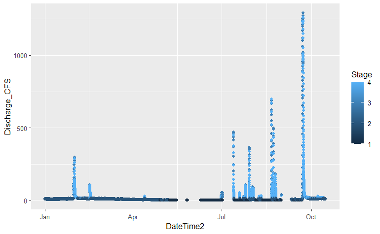

```r
# Graph all flow class data
# Missing values error is expected.
USGS_Standardized %>%
 filter(DateTime2>as.POSIXlt.character("2015-01-01")
        & DateTime2 < as.POSIXlt.character("2015-10-15")) %>%
  ggplot(aes(x=DateTime2, y=Discharge_CFS, color=Stage))+
  geom_point()
```

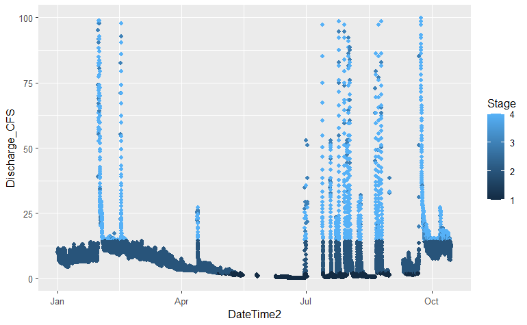

```r
# Filter to data below 100 to better view the pattern.
USGS_Standardized %>%
 filter(DateTime2>as.POSIXlt.character("2015-01-01")
        & DateTime2 < as.POSIXlt.character("2015-10-15")) %>%
  filter(Discharge_CFS<100) %>%
  ggplot(aes(x=DateTime2, y=Discharge_CFS, color=Stage))+
  geom_point()
```

## Merging the E. coli data sources and limiting to sample size.

### Data Retrieval

I have raw data from the water quality portal (EPA) a summary of ADEQ, USGS, FOSCR and NPS (Tumacacori) data along with a download of NPS-SODN quarterly sampling data (approximately 35 samples).

Data location and security: https://www.epa.gov/waterdata/water-quality-data. Data is published and public. SODN data is unpublished and should be considered provisional for this project.

Storet: https://www.waterqualitydata.us/ Country: United States of America (NWIS, STEWARDS, STORET) State: Arizona (NWIS, STORET) County: US, Arizona, Santa Cruz County (NWIS, STORET) Site type: Stream (NWIS, STEWARDS, STORET) Date from: 7/1/2009 Date to: 8/30/2022 Sample Media: Water (NWIS, STEWARDS, STORET) Characteristic Group: Microbiological (NWIS, Storet) Data profiles: Sample results (biological metadata)

SODN: Data was pulled using a sql query on a DOI/NPS server. More information can be provided by the SODN data manager, currently Helen Thomas. Data was manually manipulated to match the storet output prior to reading into R.

### Sampling Locations Information

Storet: https://www.waterqualitydata.us/ Country: United States of America (NWIS, STEWARDS, STORET) State: Arizona (NWIS, STORET) County: US, Arizona, Santa Cruz County (NWIS, STORET) Site type: Stream (NWIS, STEWARDS, STORET) Date from: 7/1/2009 Date to: 8/30/2022 Sample Media: Water (NWIS, STEWARDS, STORET) Characteristic Group: Microbiological (NWIS, Storet) Data profiles: Site Data Only

SODN: Single sampling location coordinates were provided by NPS and manually added to the storet download CSV location file.

### Sampling Location processing

The storet download file was placed into Arcmap and points within the sample range were exported to the included raw csv file. The locations for data download were chosen from the Upper Santa Cruz River. Locations are limited to North of the NIWWTP and Sonoita Creek confluence to avoid data noise from two likely point sources. All locations sampled should contain the same water without significant other inputs

### Below, The data was limited to:

1. sample location (above)
2. E. coli only (not total coliforms)
3. same method (EPA Standard Method 9223B, Colilert, sampling procedures)
4. comparable date range (Post 2009 NIWWTP significant upgrade project)

## Code

Read in the raw data files

```r
RawStoret <- "Data/Raw/ecoli_Storet_Raw.csv"
RawSODN <- "Data/Raw/ecoli_SODN_Raw.csv"
RawLocation <- "Data/Raw/ecoli_Locations_StoretandSODN.csv"

RawStoret_data <- read.csv(RawStoret)
RawSODN_data <- read.csv(RawSODN)
Locations <- read.csv(RawLocation)
```

Merge the SODN and Storet Raw Data files

```r
ecoli_data <- rbind(RawStoret_data, RawSODN_data)

# Use Janitor to clean null columns
ecoli_data<- remove_empty(ecoli_data, c("cols"))

# Remove the pre-merged raw data
rm(RawStoret_data, RawSODN_data)
```

Now we must clean up the data further. Keep only the columns which contain E. coli data. Other colifoms or enterolert (etc) procedures are within the STORET output.

Note: Fecal coliforms may also be applicable, but for the initial study I would like to stick solely to Escherichia coli. Nick Paretti (USGS) indicated that this maybe a better options due to the increased varaiblility. Fecal coliforms (non-species specific) have maximum results much more often and may be less meaningful.

```r
# STORET has standardized the output as "Escherichia coli"
ecoli_data <- ecoli_data[ecoli_data$CharacteristicName == "Escherichia coli", ]
```

I also want to remove anything with a time zone other than MST. I cannot verify if this is a typo or an actual data point. With the 9/13 data pull this is only one record.

```r
# STORET has standardized the output as "Excherichia coli"
ecoli_data <- ecoli_data[ecoli_data$ActivityStartTime.TimeZoneCode == "MST", ]
```

Remove columns with methods other than 9223B or a synonym.The methods are not standardized in STORET. It is assumed that all forms of Colilert and SM9223B represent comparable results. Colilert comes in both an 18 and 24 hour test, but they are assumed to provide a comparable output.

```r
ecoli_data <- ecoli_data[ecoli_data$ResultAnalyticalMethod.MethodName == "E coli, water, Colilert (24-28)"|
                                    ecoli_data$ResultAnalyticalMethod.MethodName ==  "COLILERT (EDBERG)"|
                                    ecoli_data$ResultAnalyticalMethod.MethodName ==  "COLILERT"|
                                    ecoli_data$ResultAnalyticalMethod.MethodName ==  "SM 9223B", ]
```

Remove dates before 2009 when the plant was updated. June 2009 Note: SODN data file had a different date format. Raw CSV output from SODN was updated on 9/13/2022

```r
ecoli_data$DateAsDate <- ymd(ecoli_data$ActivityStartDate,tz=tz)
ecoli_data$DateAsDate <-format(as.POSIXct(ecoli_data$ActivityStartDate),format='%Y-%m-%d')
ecoli_data <- ecoli_data[ecoli_data$DateAsDate >= "2009-07-01", ]
```

Merge the files based on monitoring location identifier (outputted by STORET).Monitoring locations were outputted from an ARCGIS lasso of the range between the NIWWTP/Sonoita Creek inputs and the end of the Upper Santa Cruz River. The single SODN monitoring location was manually added to the end of this file before import.

This will decrease the number of rows in the dataset because it excludes measurements outside of the study range (namely the sonoita creek data)

```r
ecoli_data<- merge(ecoli_data, Locations, by = c("MonitoringLocationIdentifier"))
```

Remove unnecessary tables.

```r
rm(Locations, RawLocation, RawSODN, RawStoret)
```

Remove any null columns created by reducing the dataset size.

```r
# Use Janitor to clean null columns
ecoli_data<- remove_empty(ecoli_data, c("cols"))
```